## Pacific Giant Salamander Weight and Abundance at Mack Creek

#### 12/4/2019

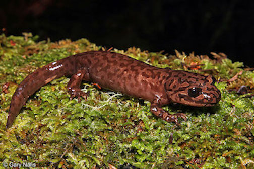

### II. Data and Methods

##### A. *Salamander Abundance in Old Growth and Clear Cut Sections of Mack Creek*

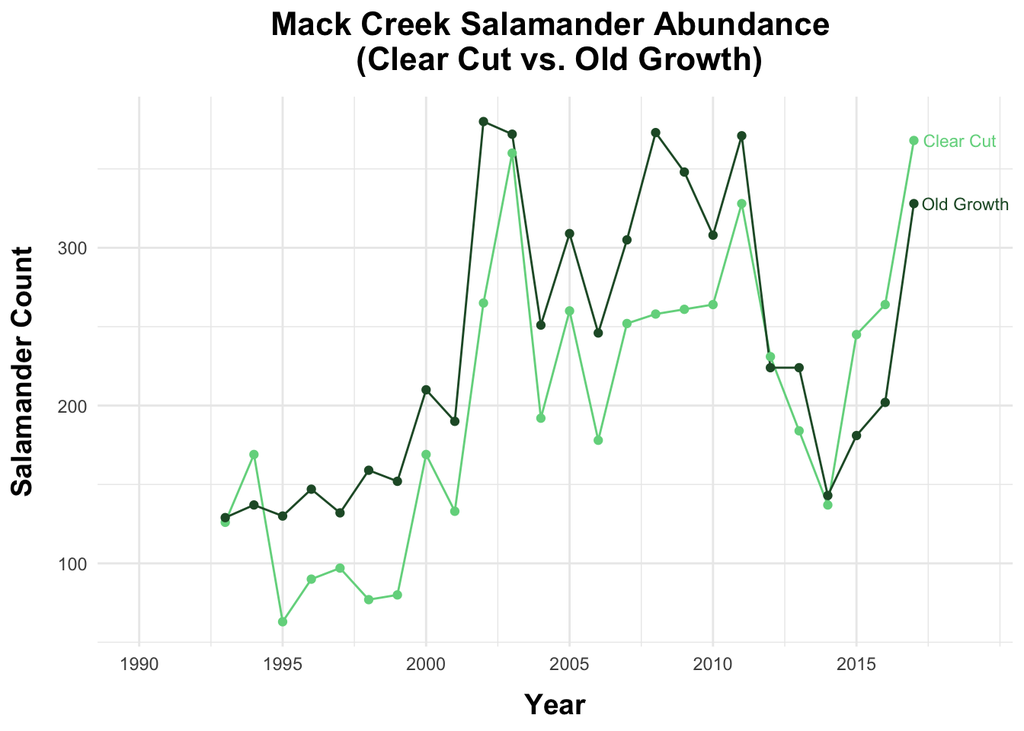

**Figure 1:Abundance of pacific giant salamander in clear cut and old growth sections of Mack Creek over time.** Counts obtained annually from 150 m reaches of stream. Points indicate individual counts obtained. Old growth forested sections of Mack Creek are represented by dark green, while light green represents counts from clear cut sections of Mack Creek. Data Source: [Aquatic Vertebrate Population Study in Mack Creek](https://portal.lternet.edu/nis/mapbrowse?packageid=knb-lter-and.4027.12)

##### B. *Salamander Abundance by Channel Type*

**Table 1. Salamander Abundance by Channel Type in Clear Cut and Old Growth sections of Mack Creek**

| Channel Type | Clear Cut | Old Growth |
| --- | --- | --- |
| Cascade | 247 (67%) | 201 (63%) |
| Pool | 31 (8%) | 45 (14%) |
| Side-channel | 90 (24%) | 74 (23%) |

##### C. *Salamander Abundance by Channel Type*

There is not a significant effect of forest condition, either old growth or clear cut, on Salamander abundance across cascades, side-channels, or pools ($\chi$<sup>2</sup>(2)=5.54, *p* = 0.06). At 67% and 63%, the majority of Salamanders from both clear cut and old growth sections of Mack Creek were found at Cascades. Side-channels accounted for the next greatest abundance of the salamanders from both sections sampled (24% and 23% repectively). Pools contained the fewest amount of salamanders accross both sections of Mack Creek, accounting for only 8% and 14% of salamanders observed.

##### D. *Salamander Weights accross clear cut and old growth forest sections (2017)*

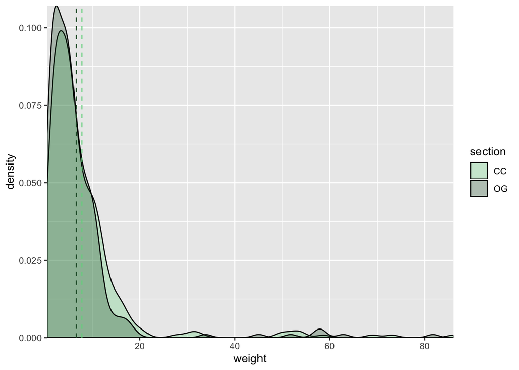

##### E. *Salamander Weights by channel type in clear cut and old growth forest sections (2017)*

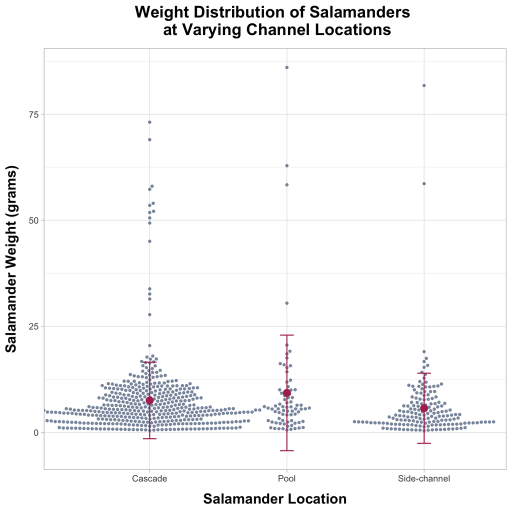

**Figure 3:Pacific giant salamander weights taken at cascades, pools, and side-channels of Mack Creek.** Gray points indicate individual salamander weights, measured in grams. Larger maroon points indicate sample means, and error bars indicate $\pm$ 1 standard deviation. Data Source: [Aquatic Vertebrate Population Study in Mack Creek](https://portal.lternet.edu/nis/mapbrowse?packageid=knb-lter-and.4027.12)

### References

**Gregory S. V. 2016.** Aquatic Vertebrate Population Study in Mack Creek, Andrews Experimental Forest, 1987 to present. Environmental Data Initiative. https://doi.org/10.6073/pasta/5de64af9c11579266ef20da2ff32f702. Dataset accessed 11/24/2019.